# statgen_sibs

Jayden Chrzanowski

2022-06-29

```r
library(tidyverse)
library(arsenal)
# reading phenotype data
phenotype <- read.csv("T2D-GENES_P1_Hispanic_phenotypes.txt", sep="")
head(phenotype)
```

```
##           FID         IID DBP SBP BPMED SMOKE EXAM_YEAR AGE SEX
## 1 SAMPLE_0001 SAMPLE_0001  51 103     0    NA      2000  57   1
## 2 SAMPLE_0002 SAMPLE_0002 109 184     1    NA      1999  60   1
## 3 SAMPLE_0003 SAMPLE_0003  92 182     1    NA      1999  50   2
## 4 SAMPLE_0004 SAMPLE_0004  78 141     1    NA      2000  59   2
## 5 SAMPLE_0005 SAMPLE_0005  89 150     1    NA      1999  41   2
## 6 SAMPLE_0006 SAMPLE_0006  57 100     0    NA      1997  75   2
```

```r
# reading genetic data
pcs <- read.csv("all_chr_eigensoft_PCs.csv")
head(pcs)
```

```
##            ID     PC1     PC2     PC3     PC4     PC5     PC6     PC7     PC8
## 1 SAMPLE_0001 -0.0613 -0.0033 -0.0087  0.0194  0.0182 -0.0194 -0.0244  0.0149
## 2 SAMPLE_0002 -0.0144 -0.0126  0.0248 -0.0131 -0.0207 -0.0316  0.0166  0.0361
## 3 SAMPLE_0003 -0.0217 -0.0124  0.0176 -0.0160 -0.0186 -0.0101  0.0191  0.0103
## 4 SAMPLE_0004 -0.0130 -0.0079 -0.0013  0.0284  0.0304 -0.0025  0.0061  0.0117
## 5 SAMPLE_0005 -0.0136 -0.0163 -0.0433 -0.0469 -0.0417  0.0141  0.0006 -0.0175
## 6 SAMPLE_0006 -0.0185 -0.0139  0.0091  0.0035  0.0029 -0.0132 -0.0029  0.0035
##       PC9    PC10
## 1  0.0180 -0.0323
## 2 -0.0100  0.0269
## 3 -0.0093 -0.0054
## 4 -0.0001 -0.0201
## 5  0.0310  0.0236
## 6 -0.0091 -0.0102
```

```r
phenotype <- subset(phenotype, select = -SMOKE) #removing smoke variable - all NAs
phenotype$HTN <- ifelse(phenotype$SBP>130, 1, ifelse(is.null(phenotype$BPMED), 1, ifelse(phenotype$BPMED==1, 1, 0))) #adding HTN variable
phenotype <- rename(phenotype, "ID" = "IID") # renaming IID in phenotype data to ID to merge with genetic data
phenotype <- merge(phenotype, pcs, by="ID") # merging genetic data by id var
```

```r
head(phenotype)
```

```
##            ID         FID DBP SBP BPMED EXAM_YEAR AGE SEX HTN     PC1     PC2
## 1 SAMPLE_0001 SAMPLE_0001  51 103     0      2000  57   1   0 -0.0613 -0.0033
## 2 SAMPLE_0002 SAMPLE_0002 109 184     1      1999  60   1   1 -0.0144 -0.0126
## 3 SAMPLE_0003 SAMPLE_0003  92 182     1      1999  50   2   1 -0.0217 -0.0124
## 4 SAMPLE_0004 SAMPLE_0004  78 141     1      2000  59   2   1 -0.0130 -0.0079
## 5 SAMPLE_0005 SAMPLE_0005  89 150     1      1999  41   2   1 -0.0136 -0.0163
## 6 SAMPLE_0006 SAMPLE_0006  57 100     0      1997  75   2   0 -0.0185 -0.0139
##       PC3     PC4     PC5     PC6     PC7     PC8     PC9    PC10
## 1 -0.0087  0.0194  0.0182 -0.0194 -0.0244  0.0149  0.0180 -0.0323
## 2  0.0248 -0.0131 -0.0207 -0.0316  0.0166  0.0361 -0.0100  0.0269
## 3  0.0176 -0.0160 -0.0186 -0.0101  0.0191  0.0103 -0.0093 -0.0054
## 4 -0.0013  0.0284  0.0304 -0.0025  0.0061  0.0117 -0.0001 -0.0201
## 5 -0.0433 -0.0469 -0.0417  0.0141  0.0006 -0.0175  0.0310  0.0236
## 6  0.0091  0.0035  0.0029 -0.0132 -0.0029  0.0035 -0.0091 -0.0102
```

```r
colnames(phenotype)
```

```
##  [1] "ID"        "FID"       "DBP"       "SBP"       "BPMED"     "EXAM_YEAR"
##  [7] "AGE"       "SEX"       "HTN"       "PC1"       "PC2"       "PC3"
## [13] "PC4"       "PC5"       "PC6"       "PC7"       "PC8"       "PC9"
## [19] "PC10"
```

```r
# Controls for summary stat tables
my_controls <- tableby.control(
  test = T,
  total = T,
  numeric.test="kwt", cat.test="chisq", #Specify Kruskal-Wallis test for numeric vars and chi square for categorical vars
  numeric.stats = c("meansd", "medianq1q3", "range", "Nmiss2"), #Display mean, sd, median, q1 and q3, range, and missing values
  cat.stats = c("countpct", "Nmiss2"),
  stats.labels=list(
    meansd = "Mean (SD)",
    medianq1q3 = "Median (Q1, Q3)",
    range = "Min - Max",
    Nmiss2 = "Missing"
  )
)
# Creating labels for variables in table
my_labels <- list(
  DBP = "Diastolic Blood Pressure",
  SBP = "Systolic Blood Pressure",
  AGE = "Age",
  SEX = "Sex",
  BPMED = "Blood Pressure Medication Status",
  HTN = "Hypertension Status"
)

# Creating a list of the PC variables
pc_list <- paste("PC", 1:10, sep="")
htn_fmla <- as.formula(paste("HTN ~ + DBP + SBP + AGE +", paste(pc_list, collapse= "+")))
sex_fmla <- as.formula(paste("SEX ~ + DBP + SBP + AGE +", paste(pc_list, collapse= "+")))
bpmed_fmla <- as.formula(paste("BPMED ~ + DBP + SBP + AGE +", paste(pc_list, collapse= "+")))

htn_table <- tableby(htn_fmla, data = phenotype, control=my_controls)
summary(htn_table, labelTranslations = my_labels, title = "Summary Statistics for Phenotypes By Hypertension")
```

Summary Statistics for Phenotypes By Hypertension

|  | 0 (N=1212) | 1 (N=639) | Total (N=1851) | p value |
| --- | --- | --- | --- | --- |
| **Diastolic Blood Pressure** |  |  |  | < 0.001 |
| Mean (SD) | 70.144 (8.953) | 79.776 (11.802) | 73.469 (11.022) |  |
| Median (Q1, Q3) | 70.500 (64.000, 76.000) | 79.000 (73.000, 86.000) | 73.000 (66.000, 80.000) |  |
| Min - Max | 32.000 - 98.000 | 37.000 - 123.000 | 32.000 - 123.000 |  |
| Missing | 0 | 0 | 0 |  |
| **Systolic Blood Pressure** |  |  |  | < 0.001 |
| Mean (SD) | 112.889 (10.623) | 148.099 (16.249) | 125.044 (21.103) |  |
| Median (Q1, Q3) | 114.000 (105.000, 121.000) | 143.000 (136.000, 154.500) | 122.000 (110.000, 137.000) |  |
| Min - Max | 66.000 - 130.000 | 130.500 - 213.000 | 66.000 - 213.000 |  |
| Missing | 0 | 0 | 0 |  |
| **Age** |  |  |  | < 0.001 |
| Mean (SD) | 45.418 (13.395) | 57.025 (12.589) | 49.425 (14.233) |  |
| Median (Q1, Q3) | 43.000 (35.000, 53.105) | 56.590 (49.000, 66.000) | 48.000 (38.000, 59.789) |  |
| Min - Max | 20.000 - 92.000 | 19.000 - 91.970 | 19.000 - 92.000 |  |
| Missing | 0 | 0 | 0 |  |
| **PC1** |  |  |  | < 0.001 |
| Mean (SD) | 0.002 (0.022) | -0.002 (0.023) | 0.001 (0.023) |  |
| Median (Q1, Q3) | 0.005 (-0.015, 0.021) | -0.002 (-0.021, 0.018) | 0.003 (-0.017, 0.020) |  |
| Min - Max | -0.070 - 0.046 | -0.053 - 0.044 | -0.070 - 0.046 |  |
| Missing | 0 | 0 | 0 |  |
| **PC2** |  |  |  | < 0.001 |
| Mean (SD) | 0.002 (0.024) | -0.002 (0.021) | 0.001 (0.023) |  |
| Median (Q1, Q3) | -0.003 (-0.016, 0.014) | -0.008 (-0.016, 0.007) | -0.005 (-0.016, 0.012) |  |
| Min - Max | -0.035 - 0.109 | -0.034 - 0.097 | -0.035 - 0.109 |  |
| Missing | 0 | 0 | 0 |  |
| **PC3** |  |  |  | 0.090 |
| Mean (SD) | -0.001 (0.023) | 0.001 (0.023) | -0.000 (0.023) |  |
| Median (Q1, Q3) | 0.001 (-0.016, 0.015) | 0.002 (-0.014, 0.016) | 0.001 (-0.015, 0.016) |  |
| Min - Max | -0.073 - 0.065 | -0.073 - 0.069 | -0.073 - 0.069 |  |
| Missing | 0 | 0 | 0 |  |
| **PC4** |  |  |  | 0.157 |
| Mean (SD) | 0.001 (0.023) | -0.001 (0.023) | 0.000 (0.023) |  |
| Median (Q1, Q3) | 0.002 (-0.014, 0.016) | -0.001 (-0.016, 0.015) | 0.000 (-0.015, 0.016) |  |
| Min - Max | -0.082 - 0.066 | -0.069 - 0.063 | -0.082 - 0.066 |  |
| Missing | 0 | 0 | 0 |  |
| **PC5** |  |  |  | 0.467 |
| Mean (SD) | 0.001 (0.024) | -0.001 (0.021) | 0.000 (0.023) |  |
| Median (Q1, Q3) | -0.000 (-0.014, 0.015) | 0.001 (-0.014, 0.014) | 0.000 (-0.014, 0.014) |  |
| Min - Max | -0.080 - 0.098 | -0.066 - 0.069 | -0.080 - 0.098 |  |
| Missing | 0 | 0 | 0 |  |
| **PC6** |  |  |  | 0.714 |
| Mean (SD) | -0.001 (0.024) | 0.001 (0.020) | -0.000 (0.023) |  |
| Median (Q1, Q3) | 0.002 (-0.012, 0.015) | 0.002 (-0.010, 0.013) | 0.002 (-0.011, 0.014) |  |
| Min - Max | -0.122 - 0.057 | -0.112 - 0.051 | -0.122 - 0.057 |  |
| Missing | 0 | 0 | 0 |  |
| **PC7** |  |  |  | 0.551 |
| Mean (SD) | 0.000 (0.022) | -0.001 (0.024) | 0.000 (0.023) |  |
| Median (Q1, Q3) | 0.004 (-0.008, 0.014) | 0.004 (-0.009, 0.014) | 0.004 (-0.009, 0.014) |  |
| Min - Max | -0.115 - 0.052 | -0.121 - 0.053 | -0.121 - 0.053 |  |
| Missing | 0 | 0 | 0 |  |
| **PC8** |  |  |  | 0.823 |
| Mean (SD) | 0.000 (0.023) | -0.000 (0.023) | -0.000 (0.023) |  |
| Median (Q1, Q3) | 0.001 (-0.015, 0.016) | 0.000 (-0.016, 0.015) | 0.000 (-0.015, 0.016) |  |
| Min - Max | -0.072 - 0.076 | -0.071 - 0.075 | -0.072 - 0.076 |  |
| Missing | 0 | 0 | 0 |  |
| **PC9** |  |  |  | 0.138 |
| Mean (SD) | 0.000 (0.023) | -0.001 (0.023) | 0.000 (0.023) |  |
| Median (Q1, Q3) | 0.000 (-0.014, 0.015) | -0.002 (-0.015, 0.012) | -0.001 (-0.014, 0.014) |  |
| Min - Max | -0.072 - 0.106 | -0.071 - 0.075 | -0.072 - 0.106 |  |
| Missing | 0 | 0 | 0 |  |
| **PC10** |  |  |  | 0.729 |
| Mean (SD) | -0.000 (0.022) | 0.000 (0.023) | -0.000 (0.023) |  |
| Median (Q1, Q3) | -0.000 (-0.016, 0.015) | 0.000 (-0.016, 0.016) | 0.000 (-0.016, 0.016) |  |
| Min - Max | -0.077 - 0.077 | -0.075 - 0.072 | -0.077 - 0.077 |  |
| Missing | 0 | 0 | 0 |  |

```r
sex_table <- tableby(sex_fmla, data = phenotype, control=my_controls)
summary(sex_table, labelTranslations = my_labels, title = "Summary Statistics for Phenotype Data By Sex")
```

Summary Statistics for Phenotype Data By Sex

|  | 1 (N=702) | 2 (N=1241) | Total (N=1943) | p value |
| --- | --- | --- | --- | --- |
| **Diastolic Blood Pressure** |  |  |  | < 0.001 |
| Mean (SD) | 76.619 (11.939) | 71.720 (10.067) | 73.469 (11.022) |  |
| Median (Q1, Q3) | 76.000 (69.000, 83.000) | 71.000 (65.000, 78.000) | 73.000 (66.000, 80.000) |  |
| Min - Max | 42.000 - 123.000 | 32.000 - 115.000 | 32.000 - 123.000 |  |
| Missing | 41 | 51 | 92 |  |
| **Systolic Blood Pressure** |  |  |  | < 0.001 |
| Mean (SD) | 127.914 (19.799) | 123.450 (21.637) | 125.044 (21.103) |  |
| Median (Q1, Q3) | 125.000 (114.000, 139.000) | 120.000 (107.000, 136.000) | 122.000 (110.000, 137.000) |  |
| Min - Max | 66.000 - 203.000 | 79.000 - 213.000 | 66.000 - 213.000 |  |
| Missing | 41 | 51 | 92 |  |
| **Age** |  |  |  | < 0.001 |
| Mean (SD) | 50.898 (14.243) | 48.700 (14.188) | 49.485 (14.243) |  |
| Median (Q1, Q3) | 50.110 (40.000, 61.000) | 47.000 (38.000, 59.000) | 48.000 (38.000, 60.000) |  |
| Min - Max | 19.000 - 87.000 | 22.190 - 92.000 | 19.000 - 92.000 |  |
| Missing | 37 | 44 | 81 |  |
| **PC1** |  |  |  | 0.829 |
| Mean (SD) | -0.000 (0.023) | 0.000 (0.022) | -0.000 (0.023) |  |
| Median (Q1, Q3) | 0.001 (-0.018, 0.020) | 0.002 (-0.018, 0.019) | 0.002 (-0.018, 0.019) |  |
| Min - Max | -0.061 - 0.045 | -0.070 - 0.046 | -0.070 - 0.046 |  |
| Missing | 0 | 0 | 0 |  |
| **PC2** |  |  |  | 0.018 |
| Mean (SD) | -0.001 (0.023) | 0.001 (0.023) | 0.000 (0.023) |  |
| Median (Q1, Q3) | -0.008 (-0.017, 0.009) | -0.004 (-0.016, 0.011) | -0.006 (-0.016, 0.010) |  |
| Min - Max | -0.035 - 0.109 | -0.034 - 0.099 | -0.035 - 0.109 |  |
| Missing | 0 | 0 | 0 |  |
| **PC3** |  |  |  | 0.080 |
| Mean (SD) | 0.001 (0.022) | -0.001 (0.023) | -0.000 (0.023) |  |
| Median (Q1, Q3) | 0.002 (-0.013, 0.016) | 0.001 (-0.016, 0.015) | 0.001 (-0.015, 0.016) |  |
| Min - Max | -0.073 - 0.069 | -0.073 - 0.065 | -0.073 - 0.069 |  |
| Missing | 0 | 0 | 0 |  |
| **PC4** |  |  |  | 0.367 |
| Mean (SD) | -0.001 (0.022) | 0.000 (0.023) | 0.000 (0.023) |  |
| Median (Q1, Q3) | -0.001 (-0.015, 0.015) | 0.001 (-0.015, 0.016) | 0.000 (-0.015, 0.015) |  |
| Min - Max | -0.069 - 0.054 | -0.082 - 0.066 | -0.082 - 0.066 |  |
| Missing | 0 | 0 | 0 |  |
| **PC5** |  |  |  | 0.088 |
| Mean (SD) | -0.001 (0.022) | 0.001 (0.023) | -0.000 (0.023) |  |
| Median (Q1, Q3) | -0.001 (-0.016, 0.013) | 0.000 (-0.014, 0.016) | -0.000 (-0.014, 0.014) |  |
| Min - Max | -0.080 - 0.070 | -0.080 - 0.098 | -0.080 - 0.098 |  |
| Missing | 0 | 0 | 0 |  |
| **PC6** |  |  |  | 0.224 |
| Mean (SD) | 0.001 (0.021) | -0.001 (0.023) | 0.000 (0.023) |  |
| Median (Q1, Q3) | 0.002 (-0.010, 0.015) | 0.002 (-0.012, 0.014) | 0.002 (-0.011, 0.014) |  |
| Min - Max | -0.112 - 0.054 | -0.122 - 0.057 | -0.122 - 0.057 |  |
| Missing | 0 | 0 | 0 |  |
| **PC7** |  |  |  | 0.208 |
| Mean (SD) | 0.001 (0.023) | -0.000 (0.022) | 0.000 (0.023) |  |
| Median (Q1, Q3) | 0.004 (-0.008, 0.015) | 0.003 (-0.009, 0.014) | 0.004 (-0.009, 0.014) |  |
| Min - Max | -0.121 - 0.053 | -0.115 - 0.052 | -0.121 - 0.053 |  |
| Missing | 0 | 0 | 0 |  |
| **PC8** |  |  |  | 0.787 |
| Mean (SD) | 0.000 (0.023) | -0.000 (0.023) | 0.000 (0.023) |  |
| Median (Q1, Q3) | 0.001 (-0.015, 0.016) | 0.001 (-0.015, 0.015) | 0.001 (-0.015, 0.016) |  |
| Min - Max | -0.072 - 0.075 | -0.071 - 0.076 | -0.072 - 0.076 |  |
| Missing | 0 | 0 | 0 |  |
| **PC9** |  |  |  | 0.540 |
| Mean (SD) | -0.000 (0.023) | 0.000 (0.023) | -0.000 (0.023) |  |
| Median (Q1, Q3) | -0.001 (-0.015, 0.015) | -0.000 (-0.013, 0.013) | -0.001 (-0.014, 0.014) |  |
| Min - Max | -0.068 - 0.106 | -0.072 - 0.086 | -0.072 - 0.106 |  |
| Missing | 0 | 0 | 0 |  |
| **PC10** |  |  |  | 0.491 |
| Mean (SD) | -0.000 (0.023) | 0.000 (0.023) | -0.000 (0.023) |  |
| Median (Q1, Q3) | -0.000 (-0.015, 0.016) | 0.001 (-0.015, 0.016) | 0.000 (-0.015, 0.016) |  |
| Min - Max | -0.075 - 0.072 | -0.077 - 0.077 | -0.077 - 0.077 |  |
| Missing | 0 | 0 | 0 |  |

```r
bpmed_table <- tableby(bpmed_fmla, data = phenotype, control=my_controls)
summary(bpmed_table, labelTranslations = my_labels, title = "Summary Statistics for Phenotype Data By Blood Pressure Medication Status")
```

Summary Statistics for Phenotype Data By Blood Pressure Medication Status

|  | 0 (N=260) | 1 (N=147) | Total (N=407) | p value |
| --- | --- | --- | --- | --- |
| **Diastolic Blood Pressure** |  |  |  | 0.061 |
| Mean (SD) | 73.303 (11.161) | 74.711 (11.126) | 73.811 (11.155) |  |
| Median (Q1, Q3) | 73.000 (66.000, 80.625) | 76.000 (67.500, 83.000) | 74.000 (67.000, 81.750) |  |
| Min - Max | 49.000 - 115.000 | 42.000 - 109.000 | 42.000 - 115.000 |  |
| Missing | 0 | 0 | 0 |  |
| **Systolic Blood Pressure** |  |  |  | < 0.001 |
| Mean (SD) | 126.839 (18.159) | 145.367 (21.082) | 133.531 (21.203) |  |
| Median (Q1, Q3) | 125.000 (114.000, 136.125) | 143.000 (132.750, 156.000) | 131.000 (118.000, 145.000) |  |
| Min - Max | 91.000 - 197.000 | 100.000 - 212.000 | 91.000 - 212.000 |  |
| Missing | 0 | 0 | 0 |  |
| **Age** |  |  |  | < 0.001 |
| Mean (SD) | 50.476 (13.539) | 61.490 (12.521) | 54.454 (14.191) |  |
| Median (Q1, Q3) | 48.990 (42.000, 59.000) | 62.248 (52.000, 71.647) | 53.000 (44.270, 64.703) |  |
| Min - Max | 19.000 - 88.630 | 35.000 - 91.970 | 19.000 - 91.970 |  |
| Missing | 0 | 0 | 0 |  |
| **PC1** |  |  |  | 0.966 |
| Mean (SD) | -0.014 (0.019) | -0.014 (0.018) | -0.014 (0.019) |  |
| Median (Q1, Q3) | -0.015 (-0.027, -0.003) | -0.015 (-0.026, -0.004) | -0.015 (-0.026, -0.003) |  |
| Min - Max | -0.061 - 0.045 | -0.052 - 0.040 | -0.061 - 0.045 |  |
| Missing | 0 | 0 | 0 |  |
| **PC2** |  |  |  | 0.917 |
| Mean (SD) | -0.014 (0.006) | -0.014 (0.007) | -0.014 (0.006) |  |
| Median (Q1, Q3) | -0.015 (-0.018, -0.011) | -0.015 (-0.018, -0.011) | -0.015 (-0.018, -0.011) |  |
| Min - Max | -0.032 - 0.005 | -0.029 - 0.015 | -0.032 - 0.015 |  |
| Missing | 0 | 0 | 0 |  |
| **PC3** |  |  |  | 0.659 |
| Mean (SD) | 0.003 (0.021) | 0.003 (0.022) | 0.003 (0.022) |  |
| Median (Q1, Q3) | 0.004 (-0.011, 0.018) | 0.003 (-0.012, 0.017) | 0.003 (-0.012, 0.018) |  |
| Min - Max | -0.056 - 0.055 | -0.059 - 0.059 | -0.059 - 0.059 |  |
| Missing | 0 | 0 | 0 |  |
| **PC4** |  |  |  | < 0.001 |
| Mean (SD) | 0.004 (0.022) | -0.003 (0.022) | 0.002 (0.022) |  |
| Median (Q1, Q3) | 0.006 (-0.009, 0.021) | -0.004 (-0.017, 0.013) | 0.003 (-0.013, 0.018) |  |
| Min - Max | -0.061 - 0.053 | -0.055 - 0.054 | -0.061 - 0.054 |  |
| Missing | 0 | 0 | 0 |  |
| **PC5** |  |  |  | 0.416 |
| Mean (SD) | 0.001 (0.021) | -0.001 (0.022) | 0.000 (0.021) |  |
| Median (Q1, Q3) | 0.001 (-0.012, 0.016) | 0.002 (-0.016, 0.014) | 0.001 (-0.013, 0.015) |  |
| Min - Max | -0.072 - 0.049 | -0.060 - 0.056 | -0.072 - 0.056 |  |
| Missing | 0 | 0 | 0 |  |
| **PC6** |  |  |  | 0.715 |
| Mean (SD) | 0.002 (0.017) | 0.002 (0.018) | 0.002 (0.017) |  |
| Median (Q1, Q3) | 0.001 (-0.009, 0.012) | 0.003 (-0.011, 0.014) | 0.002 (-0.010, 0.013) |  |
| Min - Max | -0.041 - 0.051 | -0.033 - 0.042 | -0.041 - 0.051 |  |
| Missing | 0 | 0 | 0 |  |
| **PC7** |  |  |  | 0.407 |
| Mean (SD) | 0.006 (0.018) | 0.003 (0.021) | 0.005 (0.019) |  |
| Median (Q1, Q3) | 0.007 (-0.004, 0.018) | 0.006 (-0.007, 0.016) | 0.007 (-0.004, 0.017) |  |
| Min - Max | -0.063 - 0.053 | -0.081 - 0.046 | -0.081 - 0.053 |  |
| Missing | 0 | 0 | 0 |  |
| **PC8** |  |  |  | 0.307 |
| Mean (SD) | -0.000 (0.022) | -0.003 (0.023) | -0.001 (0.023) |  |
| Median (Q1, Q3) | 0.000 (-0.016, 0.014) | -0.002 (-0.015, 0.011) | -0.001 (-0.016, 0.013) |  |
| Min - Max | -0.061 - 0.076 | -0.071 - 0.055 | -0.071 - 0.076 |  |
| Missing | 0 | 0 | 0 |  |
| **PC9** |  |  |  | 0.219 |
| Mean (SD) | 0.000 (0.019) | -0.003 (0.022) | -0.001 (0.020) |  |
| Median (Q1, Q3) | 0.000 (-0.013, 0.013) | -0.003 (-0.016, 0.009) | -0.001 (-0.014, 0.012) |  |
| Min - Max | -0.046 - 0.066 | -0.056 - 0.048 | -0.056 - 0.066 |  |
| Missing | 0 | 0 | 0 |  |
| **PC10** |  |  |  | 0.922 |
| Mean (SD) | 0.003 (0.022) | 0.003 (0.021) | 0.003 (0.022) |  |
| Median (Q1, Q3) | 0.003 (-0.012, 0.019) | 0.004 (-0.010, 0.017) | 0.004 (-0.012, 0.018) |  |
| Min - Max | -0.060 - 0.077 | -0.054 - 0.052 | -0.060 - 0.077 |  |
| Missing | 0 | 0 | 0 |  |

```r
gen_table <- tableby(~DBP + SBP + AGE, data=phenotype, control=my_controls)
summary(gen_table, labelTranslations = my_labels, title="Summary Statistics for Phenotype Data")
```

Summary Statistics for Phenotype Data

|  | Overall (N=1943) |
| --- | --- |
| **Diastolic Blood Pressure** |  |
| Mean (SD) | 73.469 (11.022) |
| Median (Q1, Q3) | 73.000 (66.000, 80.000) |
| Min - Max | 32.000 - 123.000 |
| Missing | 92 |
| **Systolic Blood Pressure** |  |
| Mean (SD) | 125.044 (21.103) |
| Median (Q1, Q3) | 122.000 (110.000, 137.000) |
| Min - Max | 66.000 - 213.000 |
| Missing | 92 |
| **Age** |  |
| Mean (SD) | 49.485 (14.243) |
| Median (Q1, Q3) | 48.000 (38.000, 60.000) |
| Min - Max | 19.000 - 92.000 |
| Missing | 81 |

```r
summary(freqlist(~SEX, data=phenotype), title="Frequency Table By Sex for Phenotype Data", labelTranslations = my_labels)
```

Frequency Table By Sex for Phenotype Data

| Sex | Freq | Cumulative Freq | Percent | Cumulative Percent |
| --- | --- | --- | --- | --- |
| 1 | 702 | 702 | 36.13 | 36.13 |
| 2 | 1241 | 1943 | 63.87 | 100.00 |

```r
summary(freqlist(~BPMED, data=phenotype), title="Frequency Table By Blood Pressure Medication Status for Phenotype Data", labelTranslations = my_labels)
```

Frequency Table By Blood Pressure Medication Status for Phenotype Data

| Blood Pressure Medication Status | Freq | Cumulative Freq | Percent | Cumulative Percent |
| --- | --- | --- | --- | --- |
| 0 | 260 | 260 | 13.38 | 13.38 |
| 1 | 147 | 407 | 7.57 | 20.95 |
| NA | 1536 | 1943 | 79.05 | 100.00 |

```r
summary(freqlist(~HTN, data=phenotype), title="Frequency Table By Hypertension Status for Phenotype Data", labelTranslations = my_labels)
```

Frequency Table By Hypertension Status for Phenotype Data

| Hypertension Status | Freq | Cumulative Freq | Percent | Cumulative Percent |
| --- | --- | --- | --- | --- |
| 0 | 1212 | 1212 | 62.38 | 62.38 |
| 1 | 639 | 1851 | 32.89 | 95.27 |
| NA | 92 | 1943 | 4.73 | 100.00 |

Hypertension has significant associations with DBP, SBP, AGE, PC1, PC2.

Sex has significant associations with DBP, SBP, AGE, and PC2

Blood Pressure Medication Status has significant assocciations with SBP, AGE, and PC4 (most significant PC yet). It makes sense for it not to have an association with DBP since high blood pressure is due to high SBP. It is interesting to note that hypertension does have a significant association with DBP. It appears that those with hypertension have a higher likelihood of having a high DBP.

There were only 3 signficant PCs in this analysis - PC1, PC2, and PC4.

There are many more missing BPMED instances (1536) compared to missing SBP and DBP (92). This does not impact hypertension as it was coded to still code depending on SBP if BPMED was null.

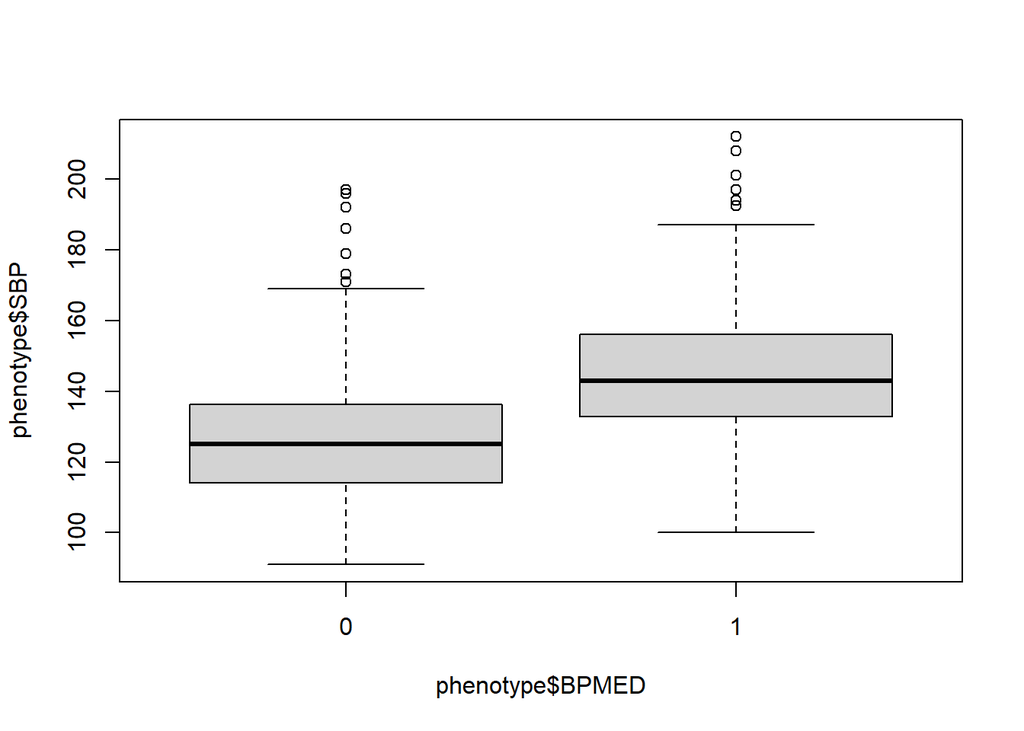

```r
boxplot(phenotype$SBP~phenotype$BPMED)
```

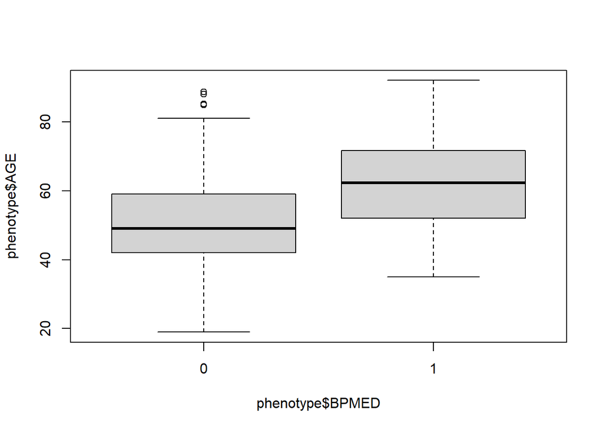

```r
boxplot(phenotype$AGE~phenotype$BPMED)
```

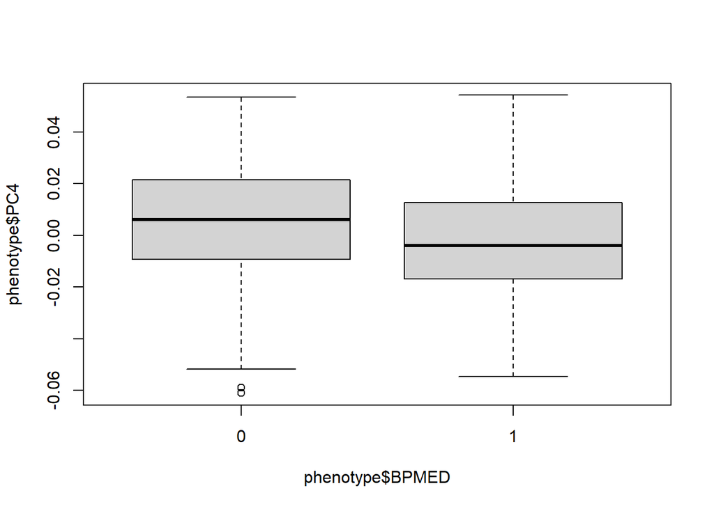

```r
boxplot(phenotype$PC4~phenotype$BPMED)
```

```r
bpmed_fmla <- as.formula(paste("BPMED ~ SBP + AGE + SEX + BPMED + HTN + + ", paste(pc_list, collapse="+")))
bpmed_model <- glm(bpmed_fmla,family=binomial(link='logit'), data=phenotype)
#summary(bpmed_model)

bpmed_model_reduc <- glm(BPMED~SBP+AGE+HTN+PC4, family=binomial(link='logit'), data=phenotype)
summary(bpmed_model_reduc)
```

```
##
## Call:
## glm(formula = BPMED ~ SBP + AGE + HTN + PC4, family = binomial(link = "logit"),
##     data = phenotype)
##
## Deviance Residuals:
##     Min       1Q   Median       3Q      Max
## -2.3242  -0.7858  -0.4329   0.8566   2.3539
##
## Coefficients:
##               Estimate Std. Error z value Pr(>|z|)
## (Intercept)  -6.713073   1.206632  -5.563 2.64e-08 ***
## SBP           0.020317   0.009419   2.157  0.03100 *
## AGE           0.050556   0.009596   5.269 1.37e-07 ***
## HTN           0.997735   0.373270   2.673  0.00752 **
## PC4         -15.366247   5.613926  -2.737  0.00620 **
## ---
## Signif. codes:  0 '***' 0.001 '**' 0.01 '*' 0.05 '.' 0.1 ' ' 1
##
## (Dispersion parameter for binomial family taken to be 1)
##
##     Null deviance: 532.43  on 406  degrees of freedom
## Residual deviance: 412.57  on 402  degrees of freedom
##   (1536 observations deleted due to missingness)
## AIC: 422.57
##
## Number of Fisher Scoring iterations: 4
```

```r
anova(bpmed_model_reduc, bpmed_model, test="Chisq")
```

```
## Analysis of Deviance Table
##
## Model 1: BPMED ~ SBP + AGE + HTN + PC4
## Model 2: BPMED ~ SBP + AGE + SEX + BPMED + HTN + +PC1 + PC2 + PC3 + PC4 +
##     PC5 + PC6 + PC7 + PC8 + PC9 + PC10
##   Resid. Df Resid. Dev Df Deviance Pr(>Chi)
## 1       402     412.57
## 2       392     407.59 10   4.9798   0.8925
```

```r
exp(coef(bpmed_model_reduc))
```

```
##  (Intercept)          SBP          AGE          HTN          PC4
## 1.214925e-03 1.020525e+00 1.051856e+00 2.712132e+00 2.120918e-07
```

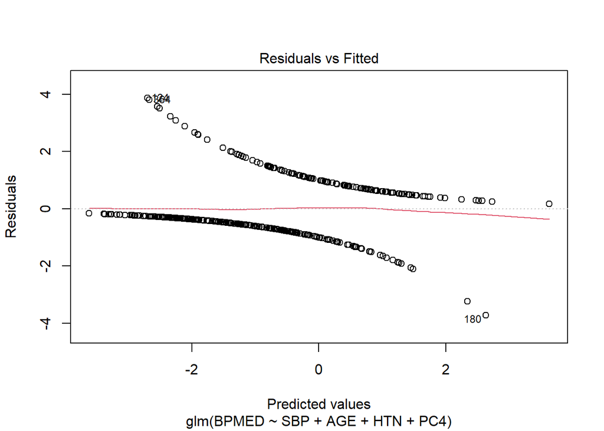

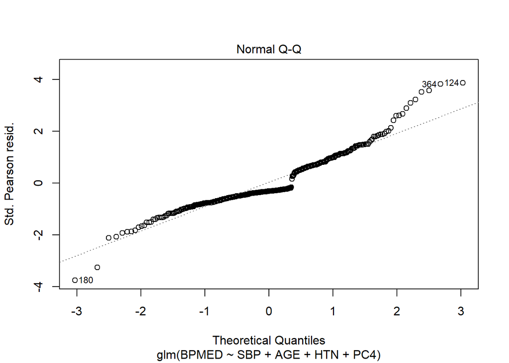

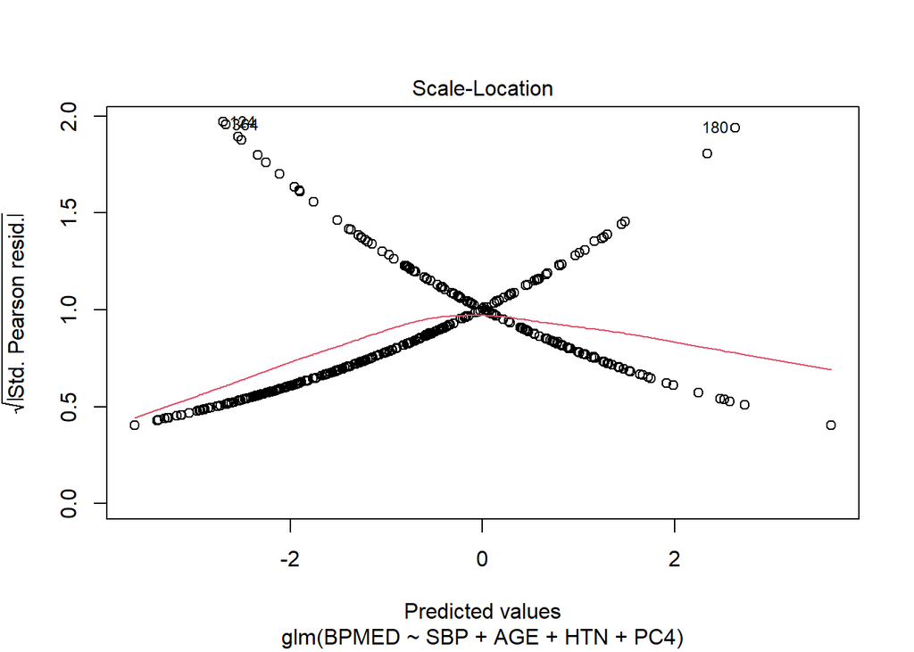

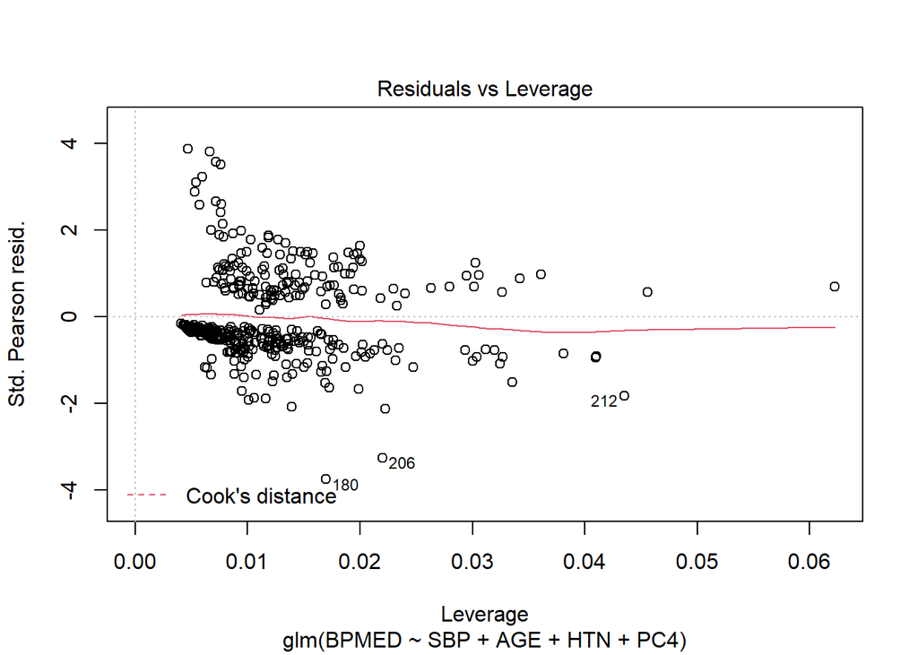

```r
plot(bpmed_model_reduc) # Little shaky on assumptions of linearity, deviation from normality present, potential influential outliers
```

```r
deviance(bpmed_model_reduc)/df.residual(bpmed_model_reduc)
```

```
## [1] 1.02629
```

The reduced model contains the variables SBP, AGE, HTN, and PC4 and appears to be a better fit model than the model with all variables as seen by the p-value of .8925 in the analysis of deviance table. Each unit increase in systolic blood pressure increases the odds of being on blood pressure medication by 1.02 (2%). Each year increase in age increases the odds of being on blood pressure medication by 1.05 (5%). Having hypertension increases the odds of being on blood pressure medication by 2.71 (171%)

It is important to note that logistic regression assumptions may not be met such as homoskedasticity as seen in the scale-location plot and normality as seen in the normal q-q plot. There may also be influential outliers present as seen in the residuals vs leverage plot with 2 points below Cook’s distance. It is likely that the influential outliers may come from the SBP variable based on the boxplots.